# How mobile use is linked to seeking medical help and contraceptive use in Rwanda

Veronica Denti

2025- July

Background

Financial exclusion leads to inequality in health. Mobile money is a significant driver of financial inclusion in Africa, with the continent accounting for over two-thirds of global mobile financial transactions. In Rwanda specifically there has been an increase in mobile money use for financial transactions: about 86% of Rwandans own or have used mobile money. Research has shown that women who were given access to mobile money services were able to receive government credits, which allowed them to access prenatal care more readily that those without that access. Mobile money use is one of the dimensions measured by the DHS survey, a nationally representative survey that collects data to evaluate population health in over 90 countries every 5 years.

Objective

This study explores the relation between mobile money use and medical help-seeking behavior and contraceptive use among women in Rwanda.

Method

Selected DHS data from Rwanda female responders collected in 2019-2020 was imported, including mobile phone ownership, and mobile phone use for financial transactions, and different categories of health seeking behavior. After excluding variables that showed redundancy, the study first assessed whether mobile phone ownership increases with age, then explores contraceptive use and mobile money use, and finally assesses whether mobile money use differs among women who perceive money to be a big issue when seeking medical help.

```
## # A tibble: 1 × 1
##   mean_age
##      <dbl>
## 1     29.1
```

```
## # A tibble: 2 × 2
##   health_insurance     n
##   <fct>            <int>
## 1 no                2455
## 2 yes              12179
```

```
## # A tibble: 2 × 2
##   has_mobile     n
##   <fct>      <int>
## 1 no          7610
## 2 yes         7024
```

```
## # A tibble: 3 × 2
##   mobile_finance     n
##   <fct>          <int>
## 1 no              1443
## 2 yes             5581
## 3 <NA>            7610
```

Results

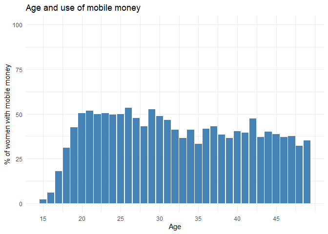

| age_group | total | mobile_money | % of women with mobile money |
| --- | --- | --- | --- |
| 15–24 | 5732 | 1824 | 31.8 |
| 25–34 | 4142 | 1915 | 46.2 |
| 35–44 | 3780 | 1495 | 39.6 |
| NA | 980 | 347 | 35.4 |

Mobile money use does not appear to affect contraceptive use Contraceptive use is similar between users and non-users of mobile money.

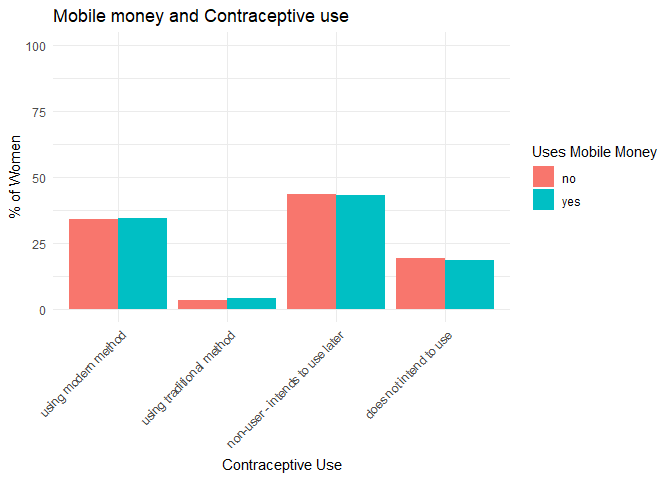

Mobile money use was linked to lower barriers to seek medical help, with 38.2% of non mobile money users reporting money to be a “big problem” when seeking medical help compared to 28.9% of mobile money users.

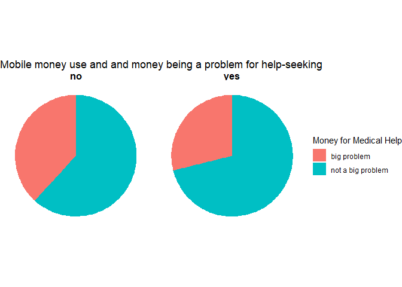

| use mobile telephone for financial transactions | getting medical help for self: getting money needed for treatment | n | percent |
| --- | --- | --- | --- |
| no | big problem | 551 | 38.2 |
| no | not a big problem | 892 | 61.8 |
| yes | big problem | 1614 | 28.9 |
| yes | not a big problem | 3967 | 71.1 |